# Deep Learning Lab Session

# First Lab Session - 1.5 Hour

# Artificial Neural Networks for Handwritten Digits Recognition

**Student 1:** Guillaume Requena  
**Student 2:** Yazid Mouline

The aim of this session is to practice with Artificial Neural Networks. Answers and experiments should be made by groups of two students. Each group should fill and run appropriate notebook cells.

Follow instructions step by step until the end and submit your complete notebook as an archive (tar -cf groupXnotebook.tar DL_lab1/). Do not forget to run all your cells before generating your final report and do not forget to include the names of all participants in the group. The lab session should be completed by March 20th 2019.

# Introduction

During this lab session, you will implement, train and test a Neural Network for the Handwritten Digits Recognition problem [[1]](http://yann.lecun.com/exdb/mnist/) with different settings of hyperparameters. You will use the MNIST dataset which was constructed from scanned documents available from the National Institute of Standards and Technology (NIST). Images of digits were taken from a variety of scanned documents, normalized in size and centered.

[figure not shown]

Figure 1: MNIST digits examples

This assignment includes a written part of programms to help you understand how to build and train your neural net and then to test your code and get results.

1. NeuralNetwork.py
2. transfer_functions.py
3. utils.py

Functions defined inside the python files mentionned above can be imported using the python command "from filename import function".

You will use the following libraries:

1. [numpy](http://cs231n.github.io/python-numpy-tutorial/) : for creating arrays and using methods to manipulate arrays;
2. [matplotlib](http://matplotlib.org/) : for making plots.

Before starting the lab, please launch the cell below. After that, you may not need to do any imports during the lab.

```python
# All imports
from NeuralNetwork import NeuralNetwork
from transfer_functions import *
from transfer_functions import softmax
from utils import *
import numpy as np
import matplotlib
```

# Section 1 : Your First Neural Network

**Part 1**: Before designing and writing your code, you will first work on a neural network by hand. Consider the following neural network with two inputs $x=(x_1,x_2)$, one hidden layer and a single output unit $y$. The initial weights are set to random values. Neurons 6 and 7 represent biases. Bias values are equal to 1. You will consider a training sample whose feature vector is $x = (0.8, 0.2)$ and whose label is $y = 0.4$.

Assume that neurons have a sigmoid activation function $f(x)=\frac{1}{(1+e^{-x})}$. The loss function $L$ is a Mean Squared Error (MSE): if $o$ denotes the output of the neural network, then the loss for a given sample $(o, y)$ is $L(o, y) = \left|\left| o - y \right|\right|^2$. In the following, you will assume that if you want to backpropagate the error on a whole batch, you will backpropagate the average error on that batch. More formally, let $((x^{(1)}, y^{(1)}), ..., (x^{(N)}, y^{(N)}))$ be a batch and $o^{(k)}$ the output associated to $x^{(k)}$. Then the total error $\bar{L}$ will be as follows:

$\bar{L} = \frac{1}{N} \sum_{k=1}^{N} L(o^{(k)}, y^{(k)})$.

[figure not shown]

Figure 2: Neural network

**Question 1.1.1**: Compute the new values of weights $w_{i,j}$ after a forward pass and a backward pass, and the outputs of the neural network before and after the backward path, when the learning rate is $\lambda$=5. $w_{i,j}$ is the weight of the connexion between neuron $i$ and neuron $j$. Please detail your computations in the cell below and print your answers.

```python
lr = 5.0
x1, x2 = 0.8, 0.2
w1_01, w1_11, w1_21, w1_02, w1_12, w1_22 = 0.2, 0.3, 0.8, -0.4, -0.5, 0.2
w2_01, w2_11, w2_21 = 0.5, -0.6, 0.4
y = 0.4

o1_1 = sigmoid(w1_11*x1 + w1_21*x2 + 1*w1_01)     # Output of the green neuron
o1_2 = sigmoid(w1_12*x1 + w1_22*x2 + 1*w1_02)     # Output of the red neuron
o2_1 = sigmoid(w2_11*o1_1 + w2_21*o1_2 + 1*w2_01) # Output of the black neuron

print("=== FORWARD PASS 1 ===")
print("o =", o2_1)

# Partial derivatives of the loss wrt weights of the second layer
dL_w2_01 = 2 * 1 * dsigmoid(w2_11*o1_1 + w2_21*o1_2 + 1*w2_01) * (o2_1 - y)
dL_w2_11 = 2 * o1_1 * dsigmoid(w2_11*o1_1 + w2_21*o1_2 + 1*w2_01) * (o2_1 - y)
dL_w2_21 = 2 * o1_2 * dsigmoid(w2_11*o1_1 + w2_21*o1_2 + 1*w2_01) * (o2_1 - y)

# Partial derivatives of the loss wrt weights of the first layer
dL_o1_1 = 2 * w2_11 * dsigmoid(w2_11*o1_1 + w2_21*o1_2 + 1*w2_01) * (o2_1 - y)
dL_o1_2 = 2 * w2_21 * dsigmoid(w2_11*o1_1 + w2_21*o1_2 + 1*w2_01) * (o2_1 - y)

dL_w1_01 = dL_o1_1 * 1 * dsigmoid(w1_11*x1 + w1_21*x2 + 1*w1_01)
dL_w1_11 = dL_o1_1 * x1 * dsigmoid(w1_11*x1 + w1_21*x2 + 1*w1_01)
dL_w1_21 = dL_o1_1 * x2 * dsigmoid(w1_11*x1 + w1_21*x2 + 1*w1_01)
dL_w1_02 = dL_o1_2 * 1 * dsigmoid(w1_12*x1 + w1_22*x2 + 1*w1_02)
dL_w1_12 = dL_o1_2 * x1 * dsigmoid(w1_12*x1 + w1_22*x2 + 1*w1_02)
dL_w1_22 = dL_o1_2 * x2 * dsigmoid(w1_12*x1 + w1_22*x2 + 1*w1_02)

# Weights updates
w1_01 -= lr*dL_w1_01
w1_11 -= lr*dL_w1_11
w1_21 -= lr*dL_w1_21
w1_02 -= lr*dL_w1_02
w1_12 -= lr*dL_w1_12
w1_22 -= lr*dL_w1_22
w2_01 -= lr*dL_w2_01
w2_11 -= lr*dL_w2_11
w2_21 -= lr*dL_w2_21

print("=== BACKWARD PASS ===")
print("w1_01 =", w1_01)
print("w1_11 =", w1_11)
print("w1_21 =", w1_21)
print("w1_02 =", w1_02)
print("w1_12 =", w1_12)
print("w1_22 =", w1_22)
print("w2_01 =", w2_01)
print("w2_11 =", w2_11)
print("w2_21 =", w2_21)

o1_1 = sigmoid(w1_11*x1 + w1_21*x2 + 1*w1_01)
o1_2 = sigmoid(w1_12*x1 + w1_22*x2 + 1*w1_02)
o2_1 = sigmoid(w2_11*o1_1 + w2_21*o1_2 + 1*w2_01)

print("=== FORWARD PASS 2 ===")
print("o =", o2_1)
```

```
=== FORWARD PASS 1 ===
o = 0.5597295991095776
=== BACKWARD PASS ===
w1_01 = 0.2540331790269339
w1_11 = 0.3432265432215471
w1_21 = 0.8108066358053868
w1_02 = -0.4341841377344243
w1_12 = -0.5273473101875394
w1_22 = 0.19316317245311515
w2_01 = 0.10637455535192786
w2_11 = -0.8541467506279605
w2_21 = 0.2745727217772572
=== FORWARD PASS 2 ===
o = 0.40648823589210104
```

**Part 2**: Neural Network Implementation

In Part 1, you computed weight updates for one sample. This is what we do for the stochastic gradient descent algorithm. However in the rest of the lab, you will be to implement the batch version of the gradient descent.

Please read all source files carefully and understand the data structures and all functions. You are to complete the missing code. First you should define the neural network (using the NeuralNetwork class, see in the NeuralNetwork.py file) and reinitialise weights. Then you will need to complete the feedforward() and the backpropagate() functions.

**Question 1.2.1**: Implement the feedforward() function.

```python
class NeuralNetwork(NeuralNetwork):
    def feedforward(self, inputs):
        transfer_f = self.transfer_f
        inputs = [x + [1.] for x in inputs]
        self.input = np.array(inputs) # Shape = [batch_size, number_of_input_values+1]
        u_1 = self.input.dot(self.W_input_to_hidden) # Compute activations for the hidden layer
              # Shape of u_1 should be [batch_size, number_of_neurons_in_hidden_layer]
        self.u_hidden = u_1
        self.o_hidden = np.ones((u_1.shape[0], u_1.shape[1]+1)) # Shape = [batch_size, number_of_hidden_values+1]
        self.o_hidden[:, :-1] = self.transfer_f(self.u_hidden)# Compute output of hidden layer
        u_2 = self.o_hidden.dot(self.W_hidden_to_output)# Compute activations for the output layer
        self.u_output = u_2
        self.o_output = self.transfer_f(self.u_output)# Compute output of output layer
```

**Question 1.2.2**: Test your implementation: create the Neural Network defined in Part 1 and see if the feedforward() function you implemented gives the same results as the ones you found by hand.

```python
# First define your neural network
model = NeuralNetwork(2,2,1)

# Then initialize the weights according to Figure 2
W_input_to_hidden = np.array([[0.3, -0.5], [0.8, 0.2], [0.2, -0.4]])
W_hidden_to_output = np.array([[-0.6], [0.4], [0.5]])
model.weights_init(W_input_to_hidden, W_hidden_to_output)

# Feed test values
test = [[0.8, 0.2]]
model.feedforward(test)

# Print the output
print("Output =", model.o_output[0,0])
```

```
Output = 0.5597295991095776
```

**Question 1.2.3**: Implement the backpropagate() function.

```python
class NeuralNetwork(NeuralNetwork):
    def backpropagate(self, targets, learning_rate=5.0):
        transfer_df = self.transfer_df
        l = learning_rate
        targets = np.array(targets) # Target outputs
        self.dL_du_output = 2*(self.o_output - targets)* transfer_df(self.u_output) # Compute partial derivative of loss with respect to activations of output layer

        self.dL_du_hidden = self.dL_du_output.dot(np.transpose(self.W_hidden_to_output[:-1]))*transfer_df(self.u_hidden) # Compute partial derivative of loss with respect to activations of hidden layer

        # Compute partial derivative of loss with respect to weights
        dW_input_to_hidden = np.transpose(self.input).dot(self.dL_du_hidden)
        dW_hidden_to_output = np.transpose(self.o_hidden).dot(self.dL_du_output)

        # Make updates
        self.W_hidden_to_output -= l*dW_hidden_to_output/len(targets)
        self.W_input_to_hidden -= l*dW_input_to_hidden/len(targets)
```

**Question 1.2.4**: Test your implementation: create the Neural Network defined in Part 1 and see if the backpropagate() function you implemented gives the same weight updates as the ones you found by hand. Do another forward pass and see if the new output is the same as the one you obtained in Question 1.1.1.

```python
# First define your neural network
model = NeuralNetwork(2,2,1)

# Then initialize the weights according to Figure 2
W_input_to_hidden = np.array([[0.3, -0.5], [0.8, 0.2], [0.2, -0.4]])
W_hidden_to_output = np.array([[-0.6], [0.4], [0.5]])
model.weights_init(W_input_to_hidden, W_hidden_to_output)

# Feed test values
test = [[0.8, 0.2]]
model.feedforward(test)

# Backpropagate
targets = [[0.4]]
model.backpropagate(targets)

# Print weights
print("W_input_to_hidden = \n", np.transpose(model.W_input_to_hidden))
print("W_hidden_to_output = \n", np.transpose(model.W_hidden_to_output))

# Feed test values again
model.feedforward(test)

# Print the output
print("Output =", model.o_output)
```

```
W_input_to_hidden =
 [[ 0.34322654  0.81080664  0.25403318]
 [-0.52734731  0.19316317 -0.43418414]]
W_hidden_to_output =
 [[-0.85414675  0.27457272  0.10637456]]
Output = [[0.40648824]]
```

Checked your implementations and found that everything was fine? Congratulations! You can move to the next section.

We found that our implementation is fine. Thank you, let's move on now

# Section 2: Handwritten Digits Recognition

The MNIST dataset consists of handwritten digit images. It is split into a training set containing 60,000 samples and a test set containing 10,000 samples. In this Lab Session, the official training set of 60,000 images is divided into an actual training set of 50,000 samples a validation set of 10,000 samples. All digit images have been size-normalized and centered in a fixed size image of 28 x 28 pixels. Images are stored in byte form: you will use the NumPy python library to convert data files into NumPy arrays that you will use to train your Neural Networks.

You will first work with a small subset of MNIST (1000 samples), then on a very small subset of MNIST (10 samples), and eventually run a model on the whole one.

The MNIST dataset is available in the Data folder. To get the training, testing and validation data, run the load_data() function.

```python
# Just run that cell ;-)
training_data, validation_data, test_data = load_data()
small_training_data = (training_data[0][:1000], training_data[1][:1000])
small_validation_data = (validation_data[0][:200], validation_data[1][:200])
indices = [1, 3, 5, 7, 2, 0, 13, 15, 17, 4]
vsmall_training_data = ([training_data[0][i] for i in indices], [training_data[1][i] for i in indices])
```

```
Loading MNIST data .....
Done.
```

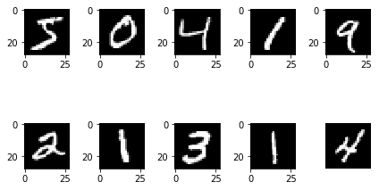

```python
# And you can run that cell if you want to see what the MNIST dataset looks like
ROW = 2
COLUMN = 5
for i in range(ROW * COLUMN):
    # train[i][0] is i-th image data with size 28x28
    image = np.array(training_data[0][i]).reshape(28, 28)
    plt.subplot(ROW, COLUMN, i+1)
    plt.imshow(image, cmap='gray')  # cmap='gray' is for black and white picture.
plt.axis('off')  # do not show axis value
plt.tight_layout()   # automatic padding between subplots
plt.show()
```

**Part 1**: Build a bigger Neural Network

The input layer of the neural network that you will build contains neurons encoding the values of the input pixels. The training data for the network will consist of many 28 by 28 pixel images of scanned handwritten digits. Thus, the input layer contains 784=28×28 units. The second layer of the network is a hidden layer. We set the number of neurons in the hidden layer to 30. The output layer contains 10 neurons.

**Question 2.1.1**: Create the network described above using the NeuralNetwork class.

```python
# Define your neural network
mnist_model = NeuralNetwork(784, 30, 10)
```

**Question 2.1.2**: Train your Neural Network on the small subset of MNIST (300 iterations) and print the new accuracy on test data. You will use small_validation_data for validation. Try different learning rates (0.1, 1.0, 10.0). You should use the train() function of the NeuralNetwork class to train your network, and the weights_init() function to reinitialize weights between tests. Print the accuracy of each model on test data using the predict() function.

```
Training time: 20.631998777389526
```

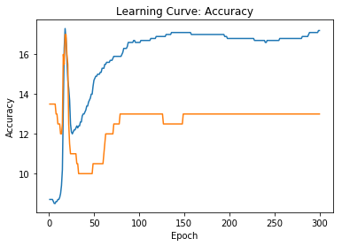

```
The accuracy of our model is 15.7% for a learning rate equal to 0.1

Training time: 20.7901029586792
```

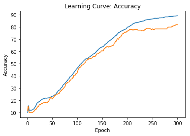

```
The accuracy of our model is 83.78% for a learning rate equal to 1

Training time: 20.248759508132935
```

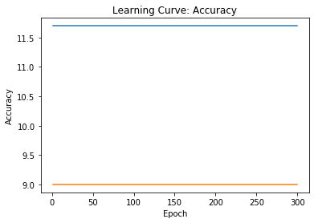

```
The accuracy of our model is 10.280000000000001% for a learning rate equal to 10
```

```python
# Train NN and print accuracy on test data
# Learning rate 0.1
# Learning rate 1.
# Learning rate 10.

learning_rate = [0.1, 1, 10]
for rate in learning_rate:
    mnist_model.weights_init()
    mnist_model.train(small_training_data, small_validation_data, iterations=300, learning_rate=rate, verbose=False)
    mnist_model.predict(test_data)
    print("The accuracy of our model is {acc}% for a learning rate equal to {lrt} \n".format(acc = (mnist_model.predict(test_data)/len(test_data[0]))*100, lrt = rate ))
```

**Question 2.1.3**: Do the same with 15 and 75 hidden neurons.

```
Training time: 19.41745686531067
```

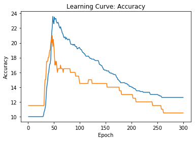

```
The accuracy of our model is 12.540000000000001% for a learning rate equal to 0.1 with 15 hidden neurons.

Training time: 19.685957431793213
```

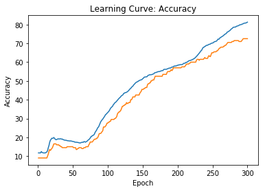

```
The accuracy of our model is 75.82% for a learning rate equal to 1 with 15 hidden neurons.

Training time: 19.537912368774414
```

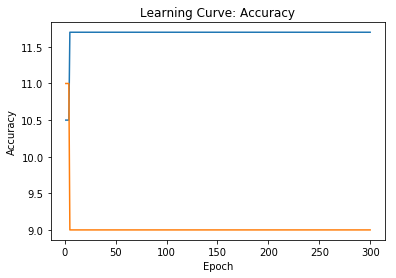

```
The accuracy of our model is 10.280000000000001% for a learning rate equal to 10 with 15 hidden neurons.

Training time: 23.147499561309814
```

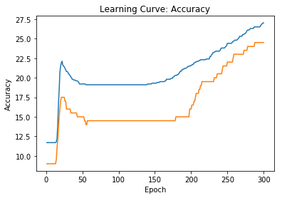

```
The accuracy of our model is 25.56% for a learning rate equal to 0.1 with 75 hidden neurons.

Training time: 23.1543071269989
```

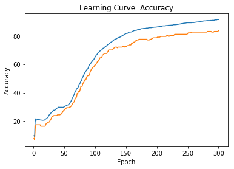

```
The accuracy of our model is 84.8% for a learning rate equal to 1 with 75 hidden neurons.

Training time: 23.324519157409668
```

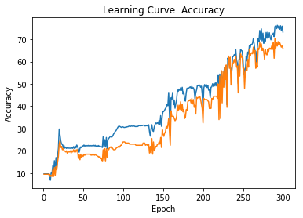

```
The accuracy of our model is 65.77% for a learning rate equal to 10 with 75 hidden neurons.
```

```python
# Define your neural network
# 15 hidden neurons
# Learning rate 0.1
# Learning rate 1.
# Learning rate 10.

learning_rate = [0.1, 1, 10]

mnist_model_15 = NeuralNetwork(784, 15, 10)

for rate in learning_rate:
    mnist_model_15.weights_init()
    mnist_model_15.train(small_training_data, small_validation_data, iterations=300, learning_rate=rate, verbose=False)
    mnist_model_15.predict(test_data)
    print("The accuracy of our model is {acc}% for a learning rate equal to {lrt} with 15 hidden neurons. \n".format(acc = (mnist_model_15.predict(test_data)/len(test_data[0]))*100, lrt = rate ))


# 75 hidden neurons
# Learning rate 0.1
# Learning rate 1.
# Learning rate 10.

mnist_model_75 = NeuralNetwork(784, 75, 10)

for rate in learning_rate:
    mnist_model_75.weights_init()
    mnist_model_75.train(small_training_data, small_validation_data, iterations=300, learning_rate=rate, verbose=False)
    mnist_model_75.predict(test_data)
    print("The accuracy of our model is {acc}% for a learning rate equal to {lrt} with 75 hidden neurons. \n".format(acc = (mnist_model_75.predict(test_data)/len(test_data[0]))*100, lrt = rate ))
```

**Question 2.1.4**: Repeat Questions 2.1.2 and 2.1.3 on the very small datasets. You will use small_validation_data for validation.

```
Training time: 1.646310567855835
```

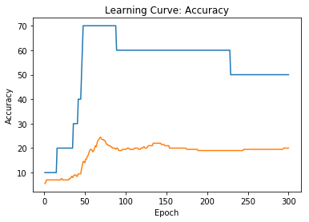

```
The accuracy of our model is 22.25% for a learning rate equal to 0.1 with 30 hidden neurons.

Training time: 1.633923053741455
```

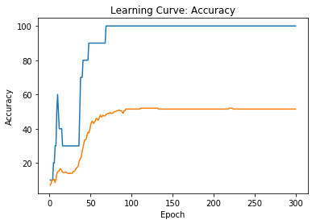

```
The accuracy of our model is 50.949999999999996% for a learning rate equal to 1 with 30 hidden neurons.

Training time: 1.6129798889160156
```

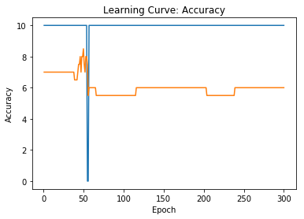

```
The accuracy of our model is 10.33% for a learning rate equal to 10 with 30 hidden neurons.

Training time: 1.5618896484375
```

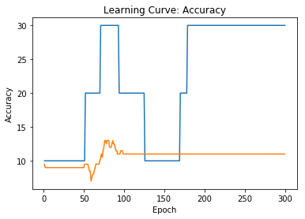

```
The accuracy of our model is 11.790000000000001% for a learning rate equal to 0.1 with 15 hidden neurons.

Training time: 1.6972589492797852
```

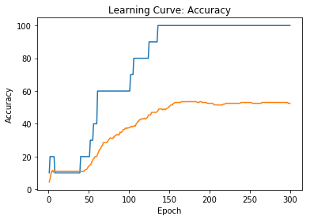

```
The accuracy of our model is 51.2% for a learning rate equal to 1 with 15 hidden neurons.

Training time: 1.5498323440551758
```

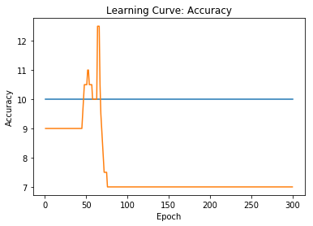

```
The accuracy of our model is 12.24% for a learning rate equal to 10 with 15 hidden neurons.

Training time: 1.898815393447876
```

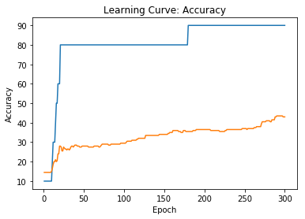

```
The accuracy of our model is 41.56% for a learning rate equal to 0.1 with 75 hidden neurons.

Training time: 2.096245527267456
```

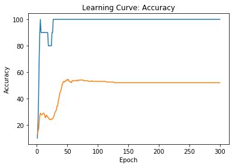

```
The accuracy of our model is 51.42% for a learning rate equal to 1 with 75 hidden neurons.

Training time: 1.913454532623291
```

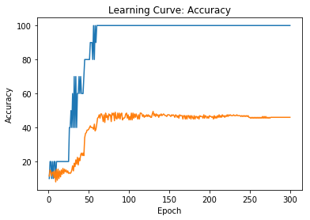

```
The accuracy of our model is 44.24% for a learning rate equal to 10 with 75 hidden neurons.
```

```python
# Train NN and print accuracy on test data
# 30 hidden neurons
# Learning rate 0.1
# Learning rate 1.
# Learning rate 10.

learning_rate = [0.1, 1, 10]

for rate in learning_rate:
    mnist_model.weights_init()
    mnist_model.train(vsmall_training_data, small_validation_data, iterations=300, learning_rate=rate, verbose=False)
    mnist_model.predict(test_data)
    print("The accuracy of our model is {acc}% for a learning rate equal to {lrt} with 30 hidden neurons. \n".format(acc = (mnist_model.predict(test_data)/len(test_data[0]))*100, lrt = rate ))

# 15 hidden neurons
# Learning rate 0.1
# Learning rate 1.
# Learning rate 10.

for rate in learning_rate:
    mnist_model_15.weights_init()
    mnist_model_15.train(vsmall_training_data, small_validation_data, iterations=300, learning_rate=rate, verbose=False)
    mnist_model_15.predict(test_data)
    print("The accuracy of our model is {acc}% for a learning rate equal to {lrt} with 15 hidden neurons. \n".format(acc = (mnist_model_15.predict(test_data)/len(test_data[0]))*100, lrt = rate ))


# 75 hidden neurons
# Learning rate 0.1
# Learning rate 1.
# Learning rate 10.

for rate in learning_rate:
    mnist_model_75.weights_init()
    mnist_model_75.train(vsmall_training_data, small_validation_data, iterations=300, learning_rate=rate, verbose=False)
    mnist_model_75.predict(test_data)
    print("The accuracy of our model is {acc}% for a learning rate equal to {lrt} with 75 hidden neurons. \n".format(acc = (mnist_model_75.predict(test_data)/len(test_data[0]))*100, lrt = rate ))
```

**Question 2.1.5**: Explain the results you obtained at Questions 2.1.2, 2.1.3 and 2.1.4.

*Answer:*

**Choice of the learning rate:** Comparing the graphs and accuracies for a fixed number of hidden neurons (15, 30, 75) we obtain better results with a learning rate equal to 1. A learning rate should not be too high nor too low. A small learning rate makes the updates too slow, it would take a bunch of iterations before attaining a optimum. That is why, the accuracies are poor. On the other hand, having a big learning rate make it impossible to reach a global optimum because it is not precise enough. Having a learning rate between allows to update reasonably fast while being enough accurate to reach an optimum, thus having a good accuracy. In our case, it is a learning rate equal to 1.

**Choice of the architecture (number of hidden neurons):** For a fixed learning rate it seems difficult to decide which architecture is best, it depends on the size of the dataset, the number of iterations as well. Where the learning rate can be chose with convincing arguments, the architecture is chosen more empirically, applying different architectures to small datasets and comparing.

An interesting fact to notice is that using a very small dataset may allow much faster computing, it worsens the efficiency of the model.

**Question 2.1.6**: Among all the numbers of hidden neurons and learning rates you tried in previous questions, which ones would you expect to achieve best performances on the whole dataset? Justify your answer.

*Answer:* As described in the previous question, to achieve best performance on the whole dataset we would choose a learning rate equal to 1. Also, the best results obtained with the smaller datasets were with an architecture of 75 hidden neurons.

**Question 2.1.7**: Train a model with the number of hidden neurons and the learning rate you chose in Question 2.1.6 and print its accuracy on the test set. You will use validation_data for validation. Training can be long on the whole dataset (~40 minutes): we suggest that you work on the optional part while waiting for the training to finish.

```
Training time: 1735.3131823539734
```

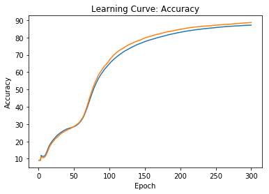

```
The accuracy of our model is 88.03% for a learning rate equal to 1 with 75 hidden neurons.
```

```python
mnist_model = NeuralNetwork(784, 75, 10)
rate = 1
mnist_model.weights_init()
mnist_model.train(training_data, validation_data, iterations=300, learning_rate=rate, verbose=False)
acc = mnist_model.predict(test_data)/len(test_data[0])*100
print("The accuracy of our model is "+ str(acc) +  "% for a learning rate equal to " + str(rate) + " with 75 hidden neurons. \n")
```

**Part 2 (optional)**: Another loss function

In classification problems, we usually replace the sigmoids in the output layer by a "softmax" function and the MSE loss by a "cross-entropy" loss. More formally, let $u = (u_1, ..., u_n)$ be the vector representing the activation of the output layer of a Neural Network. The output of that neural network is $o = (o_1, ..., o_n) = \textrm{softmax}(u)$, and

$\textrm{softmax}(u) = (\frac{e^{u_1}}{\sum_{k=1}^n e^{u_k}}, ..., \frac{e^{u_n}}{\sum_{k=1}^n e^{u_k}})$.

If $t = (t_1, ..., t_n)$ is a vector of non-negative targets such that $\sum_{k=1}^n t_k = 1$ (which is the case in classification problems, where one target is equal to 1 and all others are equal to 0), then the cross-entropy loss is defined as follows:

$L_{xe}(o, t) = - \sum_{k=1}^n t_k\log(o_k)$.

**Question 2.2.1**: Let $L_{xe}$ be the cross-entropy loss function and $u_i$, $i \in \lbrace 1, ..., n \rbrace$, be the activations of the output neurons. Let us assume that the transfer function of the output neurons is the softmax function. Targets are $t_1, ..., t_n$. Derive a formula for $\frac{\partial L_{xe}}{\partial u_i}$ (details of your calculations are not required).

**Question 2.2.2**: Implement a new feedforward() function and a new backpropagate() function adapted to the cross-entropy loss instead of the MSE loss.

```python
class NeuralNetwork(NeuralNetwork):
    def feedforward_xe(self, inputs):

        transfer_f = self.transfer_f
        inputs = [x + [1.] for x in inputs]
        self.input = np.array(inputs) # Shape = [batch_size, number_of_input_values+1]
        u_1 = self.input.dot(self.W_input_to_hidden) # Compute activations for the hidden layer
              # Shape of u_1 should be [batch_size, number_of_neurons_in_hidden_layer]
        self.u_hidden = u_1
        self.o_hidden = np.ones((u_1.shape[0], u_1.shape[1]+1)) # Shape = [batch_size, number_of_hidden_values+1]
        self.o_hidden[:, :-1] = self.transfer_f(self.u_hidden)# Compute output of hidden layer
        u_2 = self.o_hidden.dot(self.W_hidden_to_output)# Compute activations for the output layer
        self.u_output = u_2
        self.o_output = softmax(self.u_output)# Compute output of output layer

    def backpropagate_xe(self, targets, learning_rate=5.0):

        transfer_df = self.transfer_df
        l = learning_rate
        targets = np.array(targets) # Target outputs
        self.dL_du_output = - targets + softmax(self.u_output) # Compute partial derivative of loss with respect to activations of output layer

        self.dL_du_hidden = self.dL_du_output.dot(np.transpose(self.W_hidden_to_output[:-1]))*transfer_df(self.u_hidden) # Compute partial derivative of loss with respect to activations of hidden layer

        # Compute partial derivative of loss with respect to weights
        dW_input_to_hidden = np.transpose(self.input).dot(self.dL_du_hidden)
        dW_hidden_to_output = np.transpose(self.o_hidden).dot(self.dL_du_output)

        # Make updates
        self.W_hidden_to_output -= l*dW_hidden_to_output/len(targets)
        self.W_input_to_hidden -= l*dW_input_to_hidden/len(targets)
```

**Question 2.2.3**: Create a new Neural Network with the same architecture as in Question 2.1.1 and train it using the softmax cross-entropy loss.

```
Training time: 21.146963834762573
```

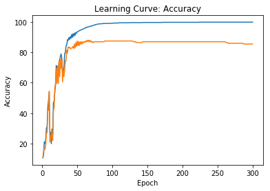

[output not shown]

```python
# Define your neural network
mnist_model_xe = NeuralNetwork(784, 30, 10)
rate = 5
# Train NN and print accuracy on validation data
mnist_model_xe.weights_init()
mnist_model_xe.train_xe(small_training_data, small_validation_data, iterations=300, learning_rate=5.0, verbose=False)
acc = mnist_model_xe.predict(test_data)/len(test_data[0])*100
print("The accuracy of our model is "+ str(acc) +  "% for a learning rate equal to " + str(rate) + " with 75 hidden neurons. \n")
```

```python
# Print accuracy on test data
```

**Question 2.2.4**: Compare your results with the MSE loss and with the cross-entropy loss.

Answer: We obtain similar results, even better, as previously but much faster and with a much smaller dataset. It is interesting to use an appropriate loss function for a problem.

**THE END!**